# 힙합엘이 크롤링

```python
import selenium as se
from selenium import webdriver as wd
from bs4 import BeautifulSoup as  bs
import time
```

저는 힙합엘이 사이트의 **국내 게시판** 글들을 크롤링해보았습니다.

도끼, 빈지노, 저스디스를 국내 게시판에 검색하고, 해당 검색 결과의 글 제목들을 모두 긁어와서 워드클라우드를 해보았습니다.

[figure not shown]

위 사진이 힙합엘이 국내 게시판의 모습입니다.

-> 검색 결과의 개수를 20으로 나눈 값 만큼 next 버튼을 눌러주며 크롤링하기

## selenium

힙합엘이 국내 게시판 진입

```python
driver = wd.Chrome(r'C:\2018-2\YBIGTA\crawling\chromedriver')
driver.get("http://hiphople.com/kboard")
```

도끼 검색.

```python
driver.find_element_by_css_selector('#bd_srch_btm_itx_2531590').send_keys('도끼')
driver.find_element_by_css_selector('#bd_2531590 > div.bd_lst_wrp > div.btm_mn.clear > div.fl > form > span.btn_img.itx_wrp > button').click()
time.sleep(2)
```

전체 글 수 확인

```python
a = driver.find_element_by_css_selector("#bd_2531590 > div.bd_lst_wrp > table > tbody > tr:nth-child(9) > td.no").text
int(a)
```

```
187
```

한페이지 전체 글 보기

```python
[x.text for x in driver.find_elements_by_class_name('hx')]
```

```
['최근 도끼 사건 관련 여론을 보면 **들이 참 많음',
 '도끼관련 핀트 왜캐 못잡음',
 '창모가 도끼 인스타에...',
 '올블랙을 다들 모르나 봄',
 '이때다 싶어 까대는 새끼들 개열받음',
 '생각해보니 도끼 노래 곧 나옵니다',
 '도끼 천만원 피해자분 인터뷰.jpg',
 "'빚투' 문제 진짜 별로네요",
 '이젠 도끼 인스타 개 사진으로도 물어뜯네',
 '개뻘글 죄송한데',
 '(성지주의) 도끼 다음앨범은 ㅆ명반일겁니다',
 '도끼 천만원밥값 발언이 이슈된게 다행이네요',
 '제일 나쁜놈들은 도끼도 돈빌려준 사람도 아님',
 '도끼 인스타',
 '힙합을 대하는 팬들과 대중의 온도차가 크긴 했던 듯',
 '도끼건은 정리하자면',
 '도끼는 그 동안의 예능 출연이 독이 된거임',
 '차피 도끼 옹호해주는건 여기 회원들이나 팬들이 대부분일듯',
 '힙x) 엘이가 힙합커뮤니티이라 그런건 이해하지만 너무 맹목적인 보호아닌가요?',
 '도끼의 대중에 대한 이미지에 타격이라..']
```

다음 페이지로 넘어가기

```python
driver.find_elements_by_css_selector('#bd_2531590 > div.bd_lst_wrp > form > fieldset > a')[-1].click()
```

### 전체코드

```python
start = time.time()

title_list = []
artist_list = ["도끼", "저스디스", "빈지노"]

driver = wd.Chrome(r'C:\2018-2\YBIGTA\crawling\chromedriver')
driver.get("http://hiphople.com/kboard")
time.sleep(2)

for ar in artist_list:
    temp_list = [] # 한명당 타이틀 리스트
    driver.get("http://hiphople.com/kboard")
    driver.find_element_by_css_selector('#bd_srch_btm_itx_2531590').send_keys(ar)
    driver.find_element_by_css_selector('#bd_2531590 > div.bd_lst_wrp > div.btm_mn.clear > div.fl > form > span.btn_img.itx_wrp > button').click()
    time.sleep(2)
    title_num = int(driver.find_element_by_css_selector("#bd_2531590 > div.bd_lst_wrp > table > tbody > tr:nth-child(9) > td.no").text)
    print(ar,"글 개수 : ",title_num)
    page_click_num = title_num//20

    for i in range(page_click_num):
        temp_list = temp_list + [x.text for x in driver.find_elements_by_class_name('hx')]
        driver.find_elements_by_css_selector('#bd_2531590 > div.bd_lst_wrp > form > fieldset > a')[-1].click()
        time.sleep(2)
    title_list.append(temp_list)

end = time.time()
print("총 걸린 시간 : ",str(end-start)+"초")
```

```
도끼 글 개수 :  187
저스디스 글 개수 :  381
빈지노 글 개수 :  92
총 걸린 시간 :  144.81121253967285초
```

- url get 하는 시간
- 검색하는 시간
- click해서 다음 페이지로 넘어가는 시간

### 너무 오래걸린다!

주소를 보면 아래와 같다

http://hiphople.com/index.php?_filter=search&mid=kboard&search_keyword=도끼&search_target=title_content&page=2&division=-13030688&last_division=-12705852

**search_keyword** 에는 검색하고자 하는 값이,

**page**에는 페이지 값이 들어가는 것을 확인할 수 있었다.

## request

```python
import requests
from bs4 import BeautifulSoup as bs
import pandas as pd
import numpy as np
```

url -> get -> bs

```python
url = "http://hiphople.com/?_filter=search&act=&vid=&mid=kboard&category=&search_keyword=도끼&search_target=title_content"
r = requests.get(url)
soup = bs(r.content,'lxml')
```

글 개수 확인

```python
soup.select('#bd_2531590 > div.bd_lst_wrp > table > tbody > tr > td.no')[8].text.replace("\n","").replace("\t","")
```

```
'187'
```

한페이지 전체 글 제목 보기

```python
[x.find('a').text.replace("\n","").replace("\t","") for x in soup.select("#bd_2531590 > div.bd_lst_wrp > table > tbody > tr > td.title")][7:]
```

```
['힙합에 대한 대중의 혐오감을 다시 한번 느낍니다',
 '최근 도끼 사건 관련 여론을 보면 **들이 참 많음',
 '도끼관련 핀트 왜캐 못잡음',
 '창모가 도끼 인스타에...',
 '올블랙을 다들 모르나 봄',
 '이때다 싶어 까대는 새끼들 개열받음',
 '생각해보니 도끼 노래 곧 나옵니다',
 '도끼 천만원 피해자분 인터뷰.jpg',
 "'빚투' 문제 진짜 별로네요",
 '이젠 도끼 인스타 개 사진으로도 물어뜯네',
 '개뻘글 죄송한데',
 '(성지주의) 도끼 다음앨범은 ㅆ명반일겁니다',
 '도끼 천만원밥값 발언이 이슈된게 다행이네요',
 '제일 나쁜놈들은 도끼도 돈빌려준 사람도 아님',
 '도끼 인스타',
 '힙합을 대하는 팬들과 대중의 온도차가 크긴 했던 듯',
 '도끼건은 정리하자면',
 '도끼는 그 동안의 예능 출연이 독이 된거임',
 '차피 도끼 옹호해주는건 여기 회원들이나 팬들이 대부분일듯',
 '힙x) 엘이가 힙합커뮤니티이라 그런건 이해하지만 너무 맹목적인 보호아닌가요?']
```

### 전체 코드

```python
start = time.time()

title_list = []
artist_list = ["도끼", "저스디스", "빈지노"]

url = "http://hiphople.com/index.php?_filter=search&mid=kboard&search_keyword=아티스트&search_target=title_content&page=페이지&division=-13017908&last_division=-12685986"
for ar in artist_list:
    temp_list = [] # 한명당 타이틀 리스트
    url_temp = url.replace("아티스트", ar)
    r = requests.get(url_temp)
    soup = bs(r.content,'lxml')

    title_num = int(soup.select('#bd_2531590 > div.bd_lst_wrp > table > tbody > tr > td.no')[8].text.replace("\n","").replace("\t",""))
    print(ar,"글 개수 : ",title_num)
    page_click_num = title_num//20

    for i in range(page_click_num):
        temp_list = temp_list + [x.find('a').text.replace("\n","").replace("\t","") for x in soup.select("#bd_2531590 > div.bd_lst_wrp > table > tbody > tr > td.title")][7:]
    title_list.append(temp_list)

end = time.time()
print("총 걸린 시간 : ",str(end-start)+"초")
```

```
도끼 글 개수 :  186
저스디스 글 개수 :  380
빈지노 글 개수 :  91
총 걸린 시간 :  4.1877241134643555초
```

예~ 빨라!

144초에서 4초로 단축~!

# 시각화

도끼, 저스디스, 빈지노 검색했을때 나온 결과들로

단순하게 단어들 카운팅 해서 빈도수로 시각화해주는 wordcloud 사용했습니다

```python
import matplotlib.pyplot as plt
%matplotlib inline

from wordcloud import WordCloud
```

```python
wc = WordCloud(font_path='C:\\WINDOWS\\Fonts\\NanumSquareRoundL.ttf',
              background_color = "white")
wc = wc.generate(str(title_list[0]))
```

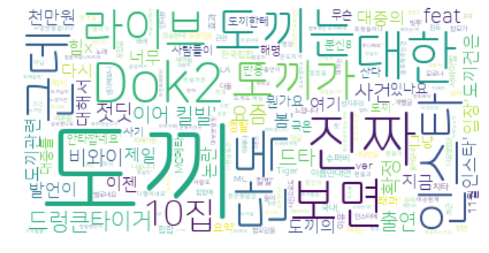

```python
plt.figure(figsize =(12,12))
plt.imshow(wc, interpolation = "bilinear")
plt.axis ("off")
plt.show()
```

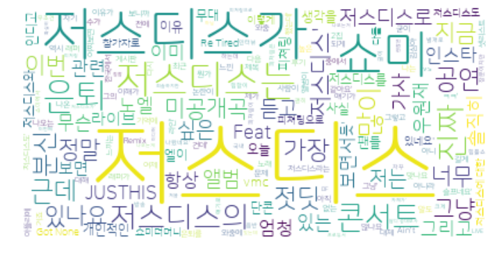

```python
wc = WordCloud(font_path='C:\\WINDOWS\\Fonts\\NanumSquareRoundL.ttf',
              background_color = "white")
wc = wc.generate(str(title_list[1]))
plt.figure(figsize =(12,12))
plt.imshow(wc, interpolation = "bilinear")
plt.axis ("off")
plt.show()
```

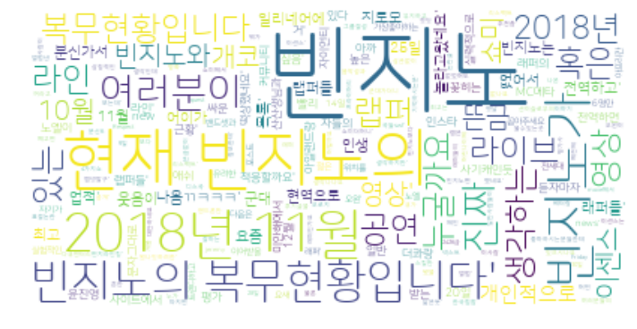

```python
wc = WordCloud(font_path='C:\\WINDOWS\\Fonts\\NanumSquareRoundL.ttf',
              background_color = "white")
wc = wc.generate(str(title_list[2]))
plt.figure(figsize =(12,12))
plt.imshow(wc, interpolation = "bilinear")
plt.axis ("off")
plt.show()
```